# IE582-HW2

## Initialization

```r
library(tidyverse)
library(reshape)
library(scatterplot3d)
library(directlabels)
library(DT)
library(ggplot2)
library(dplyr)
setwd("C:/Users/HP/Desktop/IE582/HW2")
getwd()
```

```
## [1] "C:/Users/HP/Desktop/IE582/HW2"
```

Let us read the data.

```r
x_tr = read.table("uWaveGestureLibrary_X_TRAIN")
y_tr = read.table("uWaveGestureLibrary_Y_TRAIN")
z_tr = read.table("uWaveGestureLibrary_Z_TRAIN")
```

## Part (a)

We will visualize one instance from each class. We will calculate position of instances by taking cumulative sum of acceleration.

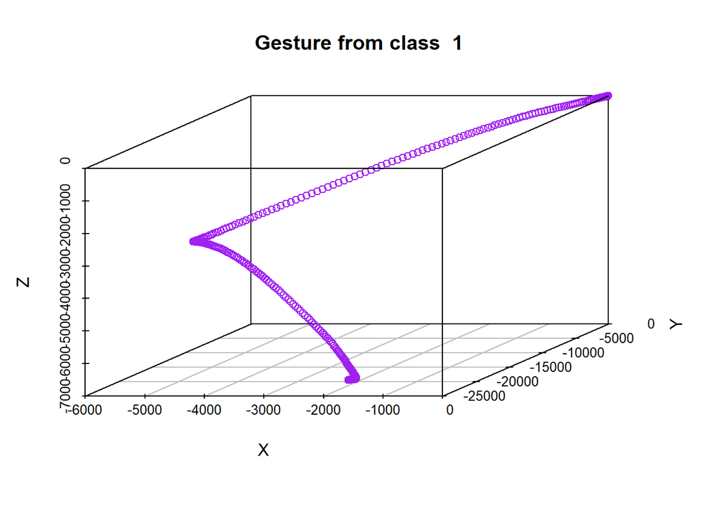

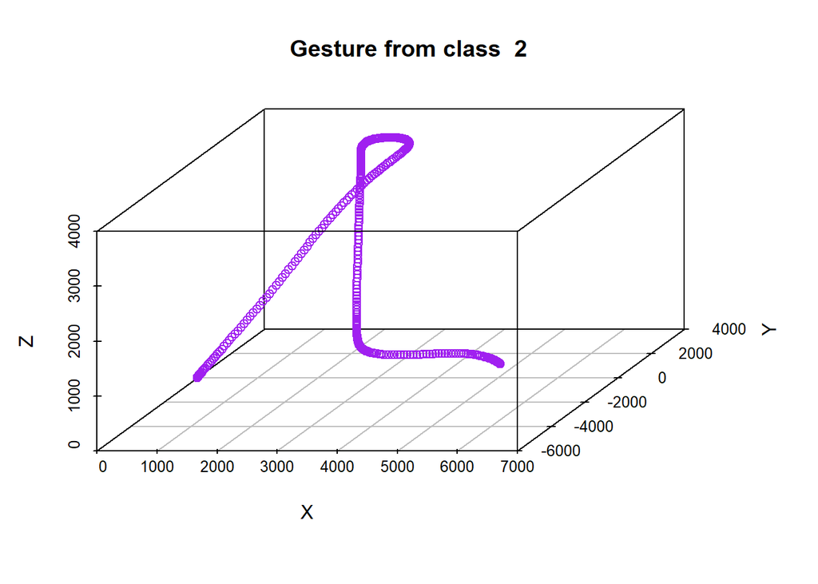

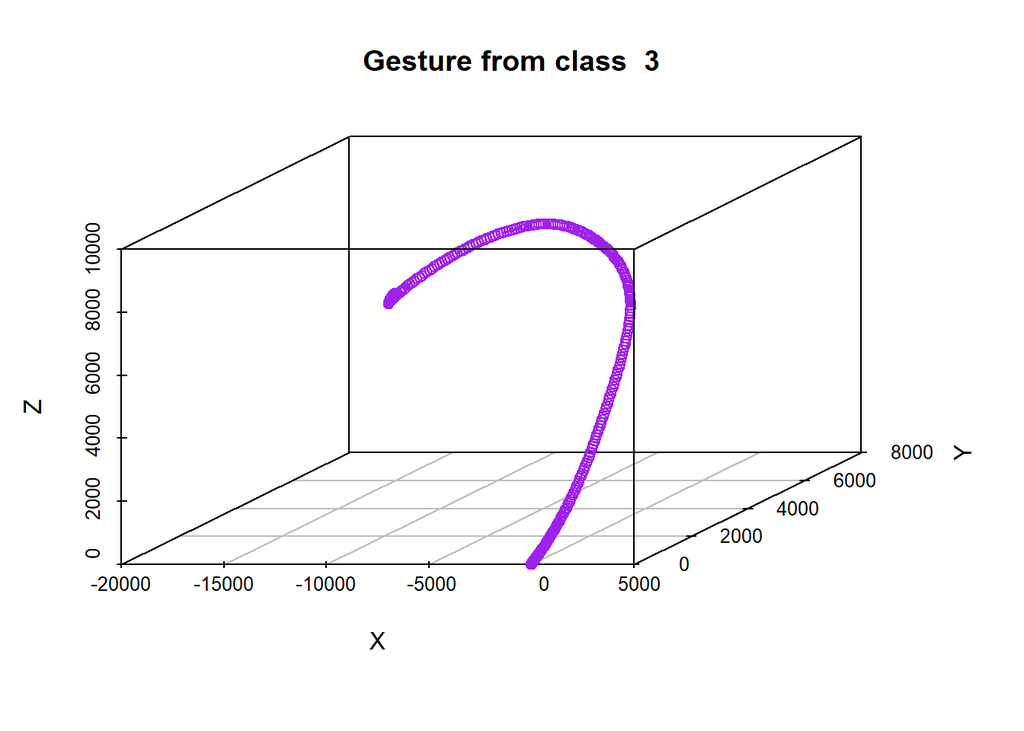

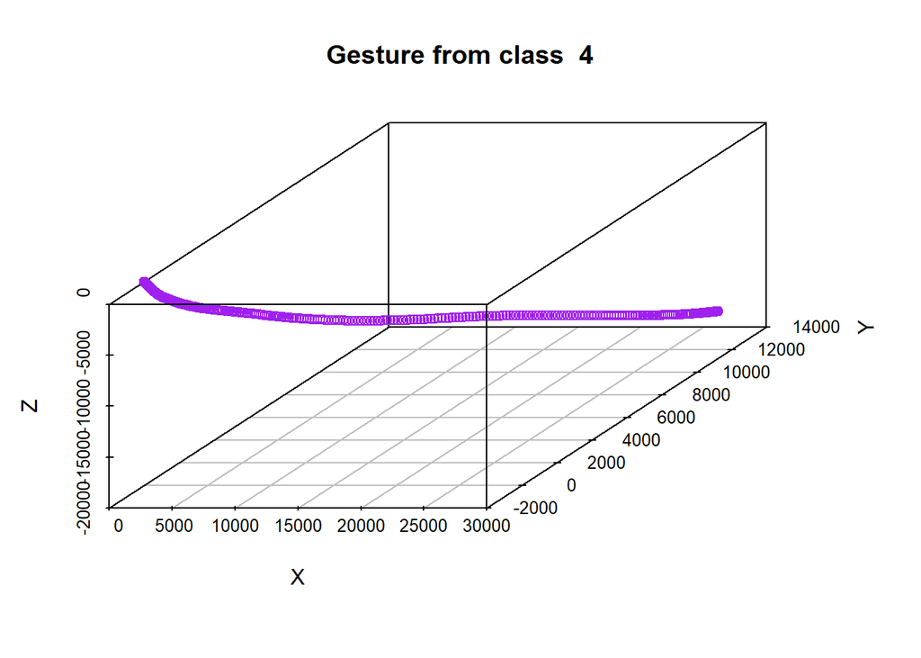

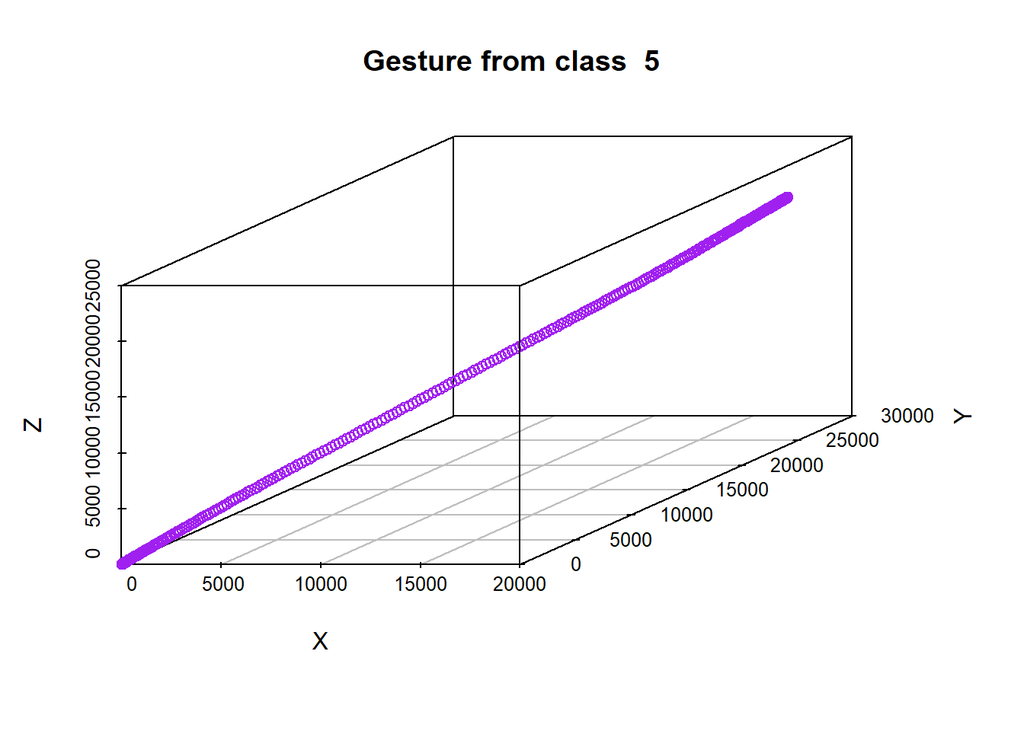

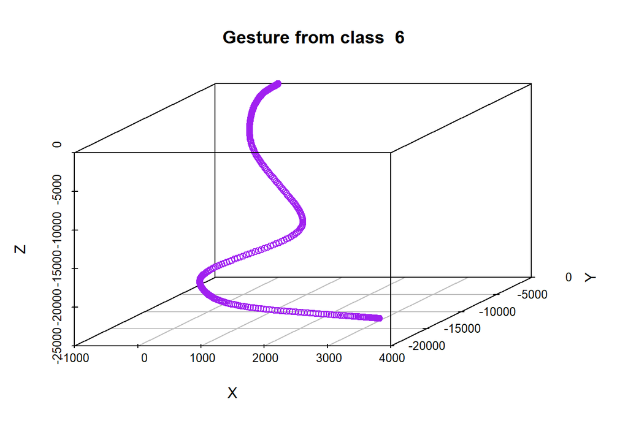

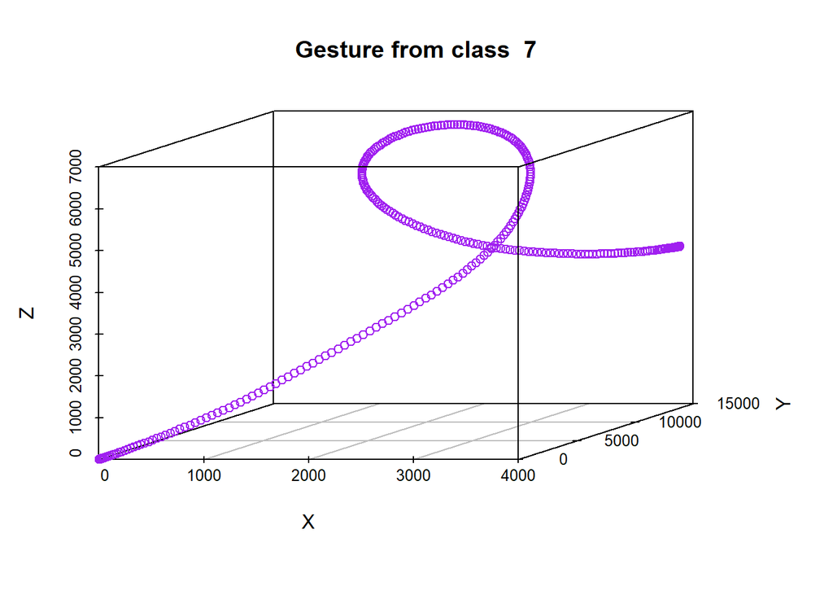

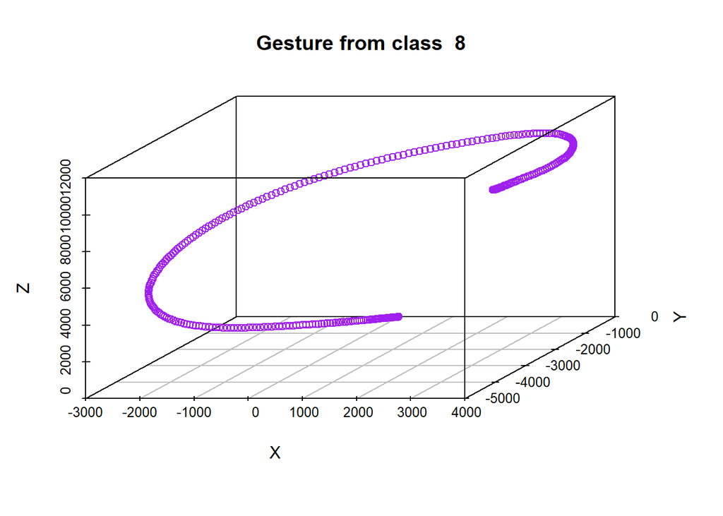

```r
transp_x_tr = as.data.frame(t(x_tr[,-1]))
x_vel=as.matrix(cumsum(transp_x_tr))
x_pos=as.matrix(cumsum(as.data.frame(x_vel)))

x_pos1=as.matrix(t(x_pos))
x_pos1=cbind(x_tr[,1],x_pos1)

transp_y_tr = as.data.frame(t(y_tr[,-1]))
y_vel=as.matrix(cumsum(transp_y_tr))
y_pos=as.matrix(cumsum(as.data.frame(y_vel)))

y_pos1=as.matrix(t(y_pos))
y_pos1=cbind(y_tr[,1],y_pos1)

transp_z_tr = as.data.frame(t(z_tr[,-1]))
z_vel=as.matrix(cumsum(transp_z_tr))
z_pos=as.matrix(cumsum(as.data.frame(z_vel)))

z_pos1=as.matrix(t(z_pos))
z_pos1=cbind(z_tr[,1],z_pos1)

indexes=c()

for (i in 1:8){
  for(j in 1:nrow(x_tr)){
    if(x_tr[j,1]==i){
      indexes[i] = j
      break
    }
  }
}

for (i in 1:8)
{
  scatterplot3d(x=x_pos1[indexes[i],-1],y=y_pos1[indexes[i],-1],z=z_pos1[indexes[i],-1], main = paste("Gesture from class ", x_pos1[indexes[i],1]), xlab="X",ylab="Y",zlab="Z", color = "purple")
}
```

## Comments:

- Visualization of gesture 1 is similar to original movement in gesture 1.
- Visualization of gesture 2 is also similar tooriginal movement in gesture 2 with its corner.
- Visualizations of gesture 3,4,5 and 6 seem very different from original shapes.
- We can see circular movements in the visualizations of gesture 7 and 8 like in the original shapes. But their direction are not the same with original movement’s direction.

## Part (b)

The problem is a type of an multivariate time series. We want to reduce it to univariate time series.Therefore, transform the data into the long format.

Then, we’ll apply PCA and visualize the reduced dimensions as time series.

```r
x_pos1=as.data.frame(x_pos1)
colnames(x_pos1)=c(0:315)

x_pos1=mutate(x_pos1, id=row_number())

molten_x = melt(x_pos1, id= c("0", "id"))
x_pos_long=data.frame(matrix(0,nrow=nrow(molten_x), ncol=ncol(molten_x)))
x_pos_long[,1]=molten_x[,2]
x_pos_long[,2]=molten_x[,3]
x_pos_long[,3]=molten_x[,4]
x_pos_long[,4]=molten_x[,1]

colnames(x_pos_long)= c("time_series_id", "time_index", "X","class")
#####

y_pos1=as.data.frame(y_pos1)
colnames(y_pos1)=c(0:315)

y_pos1=mutate(y_pos1, id=row_number())

molten_y = melt(y_pos1, id= c("0", "id"))
y_pos_long=data.frame(matrix(0,nrow=nrow(molten_y), ncol=ncol(molten_y)))
y_pos_long[,1]=molten_y[,2]
y_pos_long[,2]=molten_y[,3]
y_pos_long[,3]=molten_y[,4]
y_pos_long[,4]=molten_y[,1]

colnames(y_pos_long)= c("time_series_id", "time_index", "Y","class")

####
z_pos1=as.data.frame(z_pos1)
colnames(z_pos1)=c(0:315)

z_pos1=mutate(z_pos1, id=row_number())

molten_z = melt(z_pos1, id= c("0", "id"))
z_pos_long=data.frame(matrix(0,nrow=nrow(molten_z), ncol=ncol(molten_z)))
z_pos_long[,1]=molten_z[,2]
z_pos_long[,2]=molten_z[,3]
z_pos_long[,3]=molten_z[,4]
z_pos_long[,4]=molten_z[,1]

colnames(z_pos_long)= c("time_series_id", "time_index", "Z","class")

x_1 = c()
x_1=x_pos_long[,4]
xyz_pos_long=cbind(x_pos_long[,-4],y_pos_long[,3],z_pos_long[,3],x_pos_long[,4])

colnames(xyz_pos_long)=c("time_series_id", "time_index", "X", "Y","Z","class")

princ <- princomp(xyz_pos_long[,3:5], cor=TRUE)
print(summary(princ, loadings=TRUE))
```

```
## Importance of components:
##                           Comp.1    Comp.2    Comp.3
## Standard deviation     1.2724995 1.0380930 0.5505524
## Proportion of Variance 0.5397517 0.3592124 0.1010360
## Cumulative Proportion  0.5397517 0.8989640 1.0000000
##
## Loadings:
##   Comp.1 Comp.2 Comp.3
## X  0.209  0.908  0.362
## Y  0.723  0.105 -0.683
## Z  0.658 -0.404  0.635
```

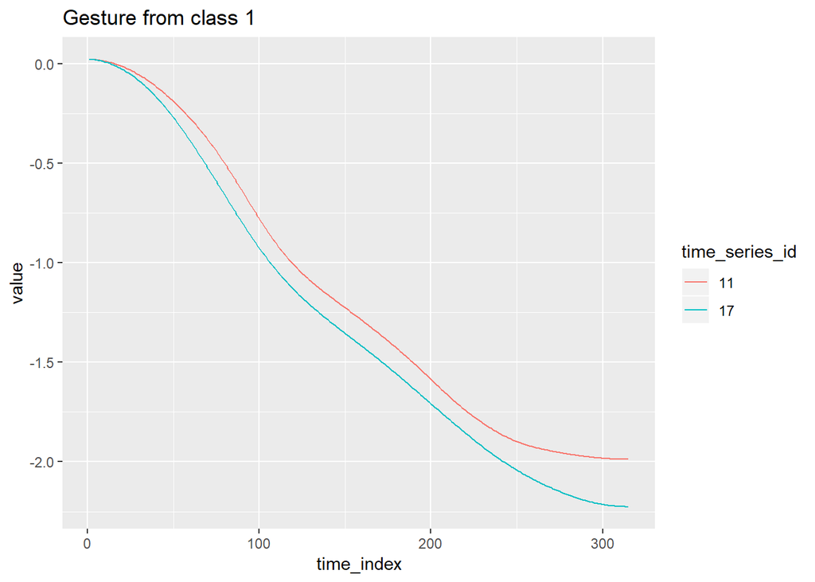

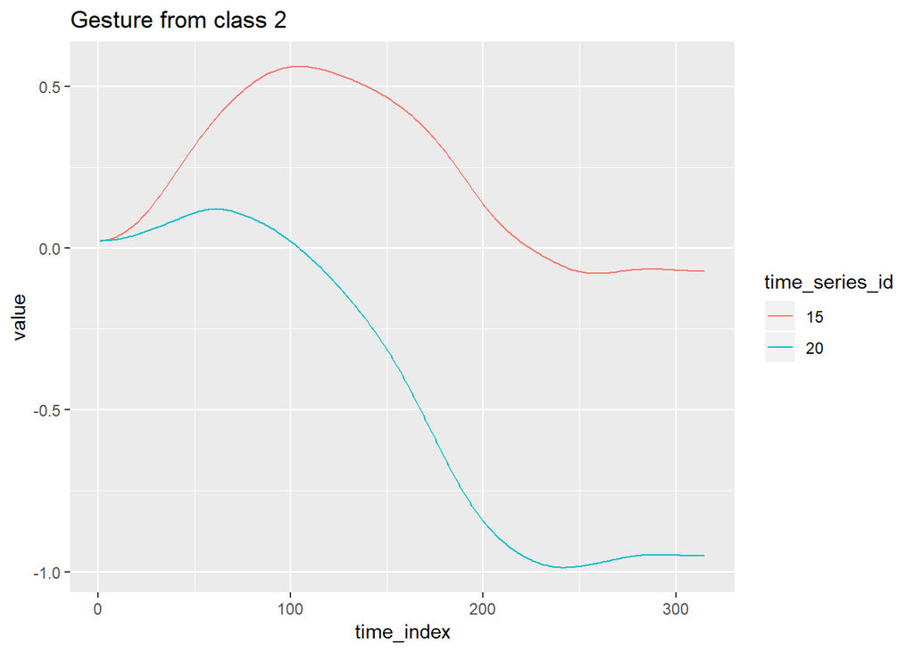

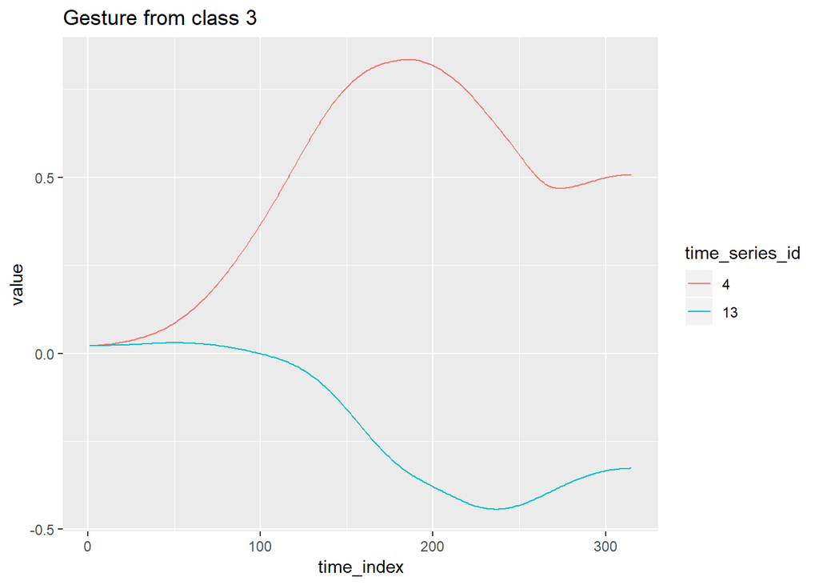

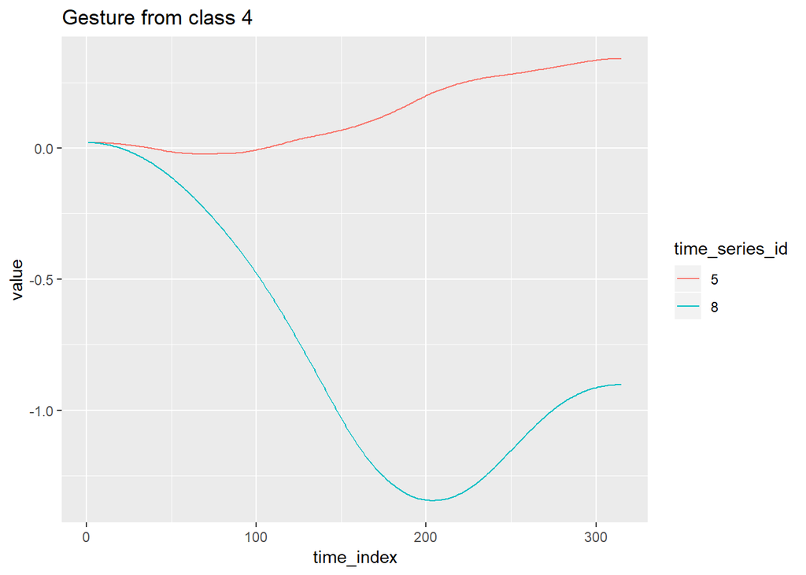

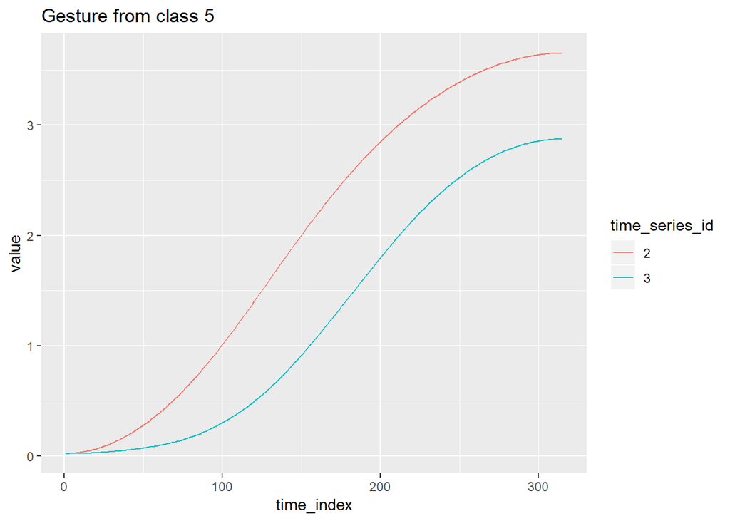

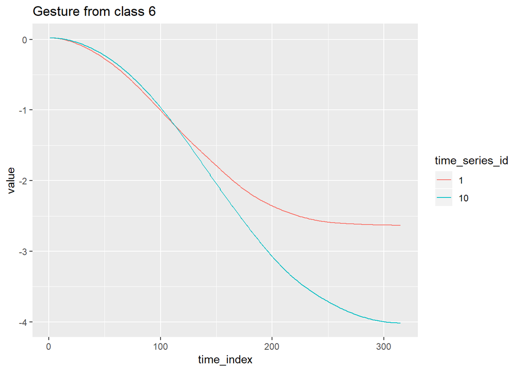

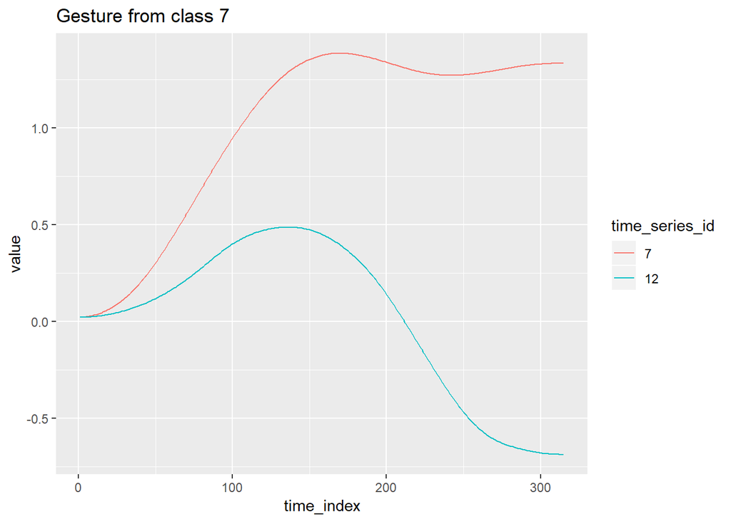

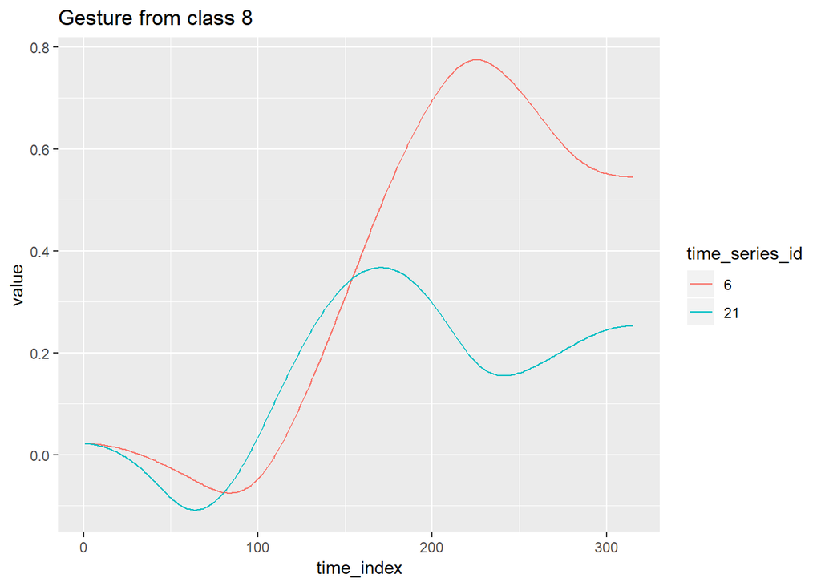

```r
pre = predict(princ,xyz_pos_long[,3:5])
xyz_pos_uni = mutate(xyz_pos_long,value=pre[,1])
pred_xyz=data.frame()
pred_xyz = subset(xyz_pos_uni, select =-c(X,Y,Z))

indexes=c()

for (i in 1:8){
  for(j in 1:nrow(x_tr)){
    if(x_tr[j,1]==i){
      indexes[i] = j
      break
    }
  }
}

indexes2=c()
count=rep(0,8)

for (i in 1:16){
  for(j in 1:nrow(x_tr)){
    if(x_tr[j,1]==i){
      indexes2[i] = j
      count[i]=count[i]+1

      if(count[i]==2)
      {
        break
      }
    }
  }
}

indexess=append(indexes,indexes2)

new_one=filter(pred_xyz, time_series_id %in% indexess)

new_one$time_index=as.numeric(new_one$time_index)
new_one$time_series_id=as.factor(new_one$time_series_id)
new_one$class=as.factor(new_one$class)

for(i in 1:8)
  {
    plo=ggplot(subset(new_one,time_series_id==indexes[i] | time_series_id==indexes2[i]), aes(x=time_index, y=value, colour=time_series_id)) + geom_line() + xlab("time_index") + ylab("value") + ggtitle(paste("Gesture from class",i))
    print(plo)
  }
```

Comp.1 covers 54 % of the variance, whereas Comp.2 and Comp.3 covers 36% and 10% of the variance respectively. Therefore, we will select *Comp.1*, which hast the highest percentage of variance covering, for dimensionality reduction.

## Part (c)

We will apply PCA to each gesture class seperately

```r
#class1

xyz_1 = subset(xyz_pos_long, class==1)
pirinc1=princomp(xyz_1[,3:5], cor = TRUE)
print(summary(pirinc1,loadings=TRUE))
```

```
## Importance of components:
##                           Comp.1    Comp.2    Comp.3
## Standard deviation     1.2932492 1.0091473 0.5559931
## Proportion of Variance 0.5574978 0.3394594 0.1030428
## Cumulative Proportion  0.5574978 0.8969572 1.0000000
##
## Loadings:
##   Comp.1 Comp.2 Comp.3
## X  0.119  0.973  0.198
## Y  0.693 -0.224  0.685
## Z  0.711        -0.701
```

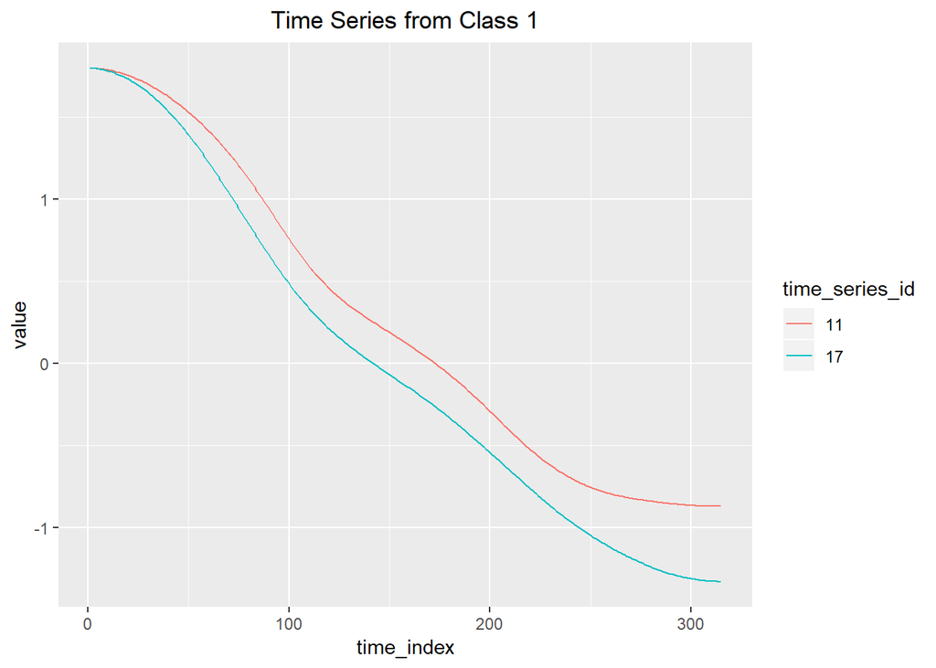

```r
pre1 = predict(pirinc1,xyz_1[,3:5])
xyz_1_uni = mutate(xyz_1,value=pre1[,1])
xyz_1_uni = mutate(xyz_1_uni, time_series_id=as.factor(time_series_id), time_index=as.numeric(time_index))
xyz_1_uni = subset(xyz_1_uni,select=-c(X,Y,Z))
xyz_1_uni = filter(xyz_1_uni, time_series_id==indexess[1] | time_series_id==indexess[9])

ggplot(xyz_1_uni) + geom_line(aes(x=time_index, y=value, colour=time_series_id)) + xlab("time_index") + ylab("value") + theme(plot.title=element_text(hjust = 0.5)) + ggtitle("Time Series from Class 1")
```

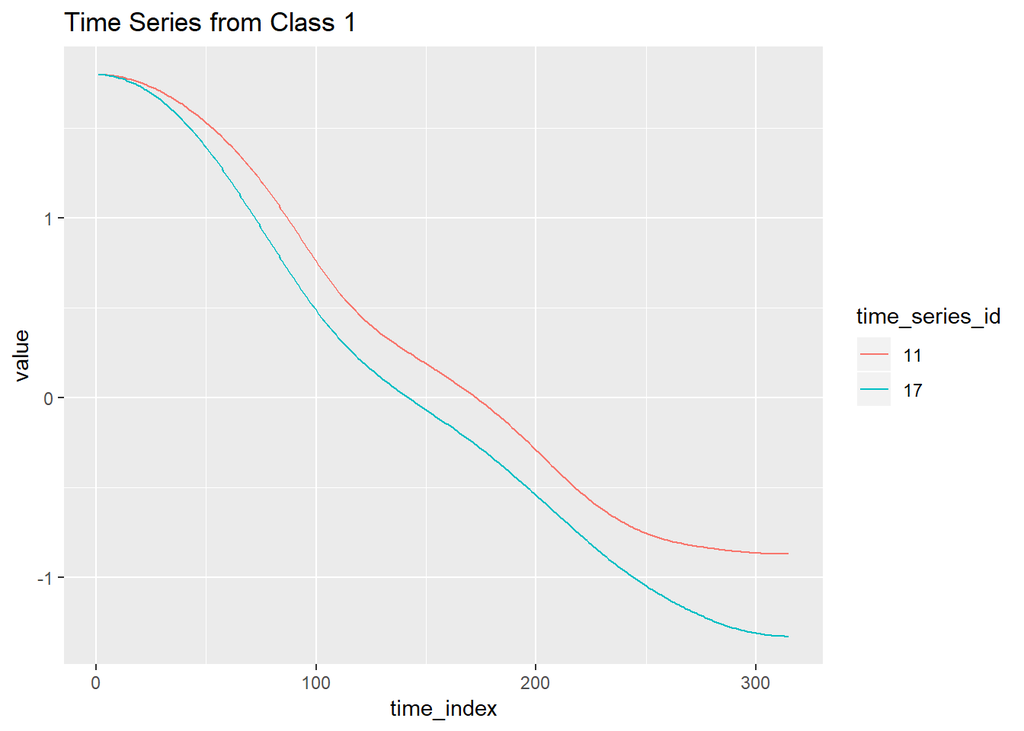

```r
ggplot(xyz_1_uni) + geom_line(aes(x=time_index, y=value, colour=time_series_id)) + xlab("time_index") + ylab("value")+ ggtitle("Time Series from Class 1")
```

```r
#class2

xyz_2 = subset(xyz_pos_long, class==2)
pirinc2=princomp(xyz_2[,3:5], cor = TRUE)
print(summary(pirinc2,loadings=TRUE))
```

```
## Importance of components:
##                           Comp.1    Comp.2    Comp.3
## Standard deviation     1.1286537 0.9457021 0.9120243
## Proportion of Variance 0.4246197 0.2981175 0.2772628
## Cumulative Proportion  0.4246197 0.7227372 1.0000000
##
## Loadings:
##   Comp.1 Comp.2 Comp.3
## X  0.535  0.814  0.224
## Y  0.613 -0.192 -0.767
## Z  0.581 -0.548  0.602
```

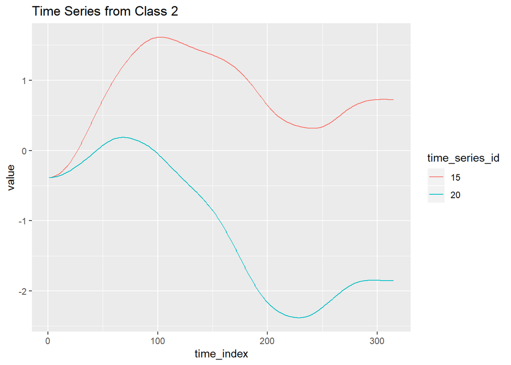

```r
pre2 = predict(pirinc2,xyz_2[,3:5])
xyz_2_uni = mutate(xyz_2,value=pre2[,1])
xyz_2_uni = mutate(xyz_2_uni, time_series_id=as.factor(time_series_id), time_index=as.numeric(time_index))
xyz_2_uni = subset(xyz_2_uni,select=-c(X,Y,Z))
xyz_2_uni = filter(xyz_2_uni, time_series_id==indexess[2] | time_series_id==indexess[10])

ggplot(xyz_2_uni) + geom_line(aes(x=time_index, y=value, colour=time_series_id)) + xlab("time_index") + ylab("value")+ ggtitle("Time Series from Class 2")
```

```r
#class3

xyz_3 = subset(xyz_pos_long, class==3)
pirinc3=princomp(xyz_3[,3:5], cor = TRUE)
print(summary(pirinc3,loadings=TRUE))
```

```
## Importance of components:
##                           Comp.1    Comp.2    Comp.3
## Standard deviation     1.2156489 1.0027730 0.7187794
## Proportion of Variance 0.4926008 0.3351846 0.1722146
## Cumulative Proportion  0.4926008 0.8277854 1.0000000
##
## Loadings:
##   Comp.1 Comp.2 Comp.3
## X  0.709         0.705
## Y  0.371  0.847 -0.380
## Z -0.599  0.532  0.599
```

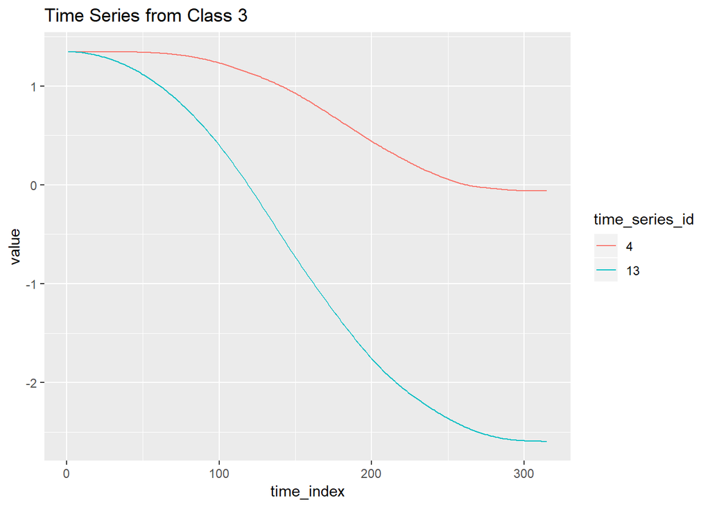

```r
pre3 = predict(pirinc3,xyz_3[,3:5])
xyz_3_uni = mutate(xyz_3,value=pre3[,1])
xyz_3_uni = mutate(xyz_3_uni, time_series_id=as.factor(time_series_id), time_index=as.numeric(time_index))
xyz_3_uni = subset(xyz_3_uni,select=-c(X,Y,Z))
xyz_3_uni = filter(xyz_3_uni, time_series_id==indexess[3] | time_series_id==indexess[11])
ggplot(xyz_3_uni) + geom_line(aes(x=time_index, y=value, colour=time_series_id)) + xlab("time_index") + ylab("value")+ ggtitle("Time Series from Class 3")
```

```r
#class4

xyz_4 = subset(xyz_pos_long, class==4)
pirinc4=princomp(xyz_4[,3:5], cor = TRUE)
print(summary(pirinc4,loadings=TRUE))
```

```
## Importance of components:
##                           Comp.1    Comp.2    Comp.3
## Standard deviation     1.2855781 0.9914895 0.6035210
## Proportion of Variance 0.5509037 0.3276838 0.1214125
## Cumulative Proportion  0.5509037 0.8785875 1.0000000
##
## Loadings:
##   Comp.1 Comp.2 Comp.3
## X  0.702         0.711
## Y  0.674  0.285 -0.681
## Z -0.230  0.958  0.173
```

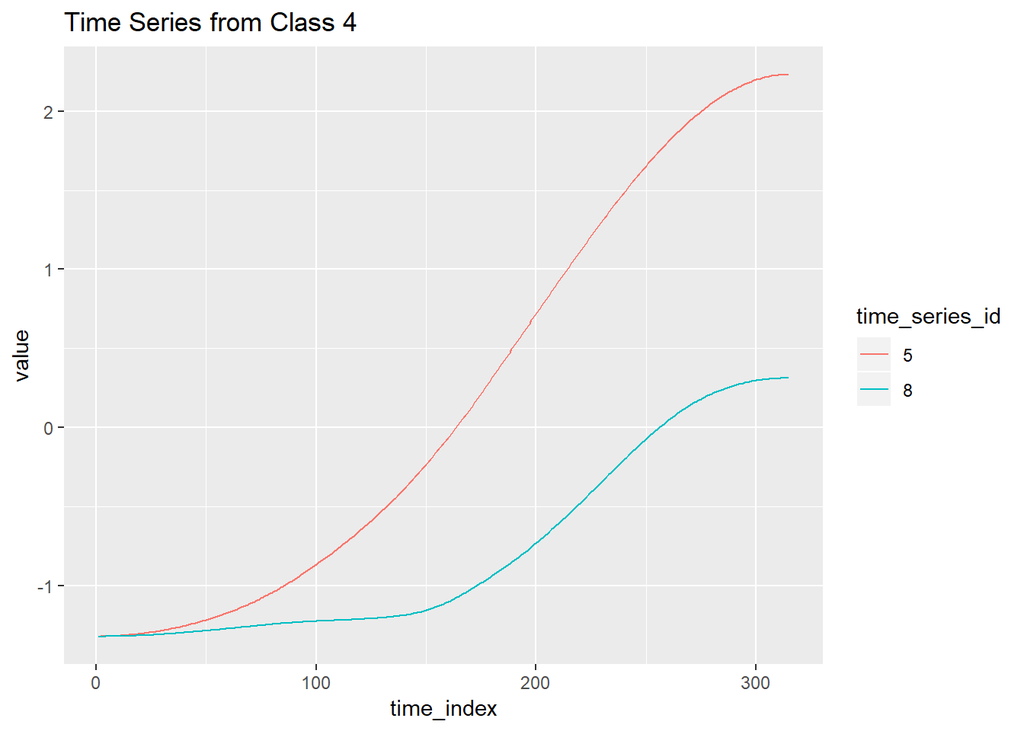

```r
pre4 = predict(pirinc4,xyz_4[,3:5])
xyz_4_uni = mutate(xyz_4,value=pre4[,1])
xyz_4_uni = mutate(xyz_4_uni, time_series_id=as.factor(time_series_id), time_index=as.numeric(time_index))
xyz_4_uni = subset(xyz_4_uni,select=-c(X,Y,Z))
xyz_4_uni = filter(xyz_4_uni, time_series_id==indexess[4] | time_series_id==indexess[12])
ggplot(xyz_4_uni) + geom_line(aes(x=time_index, y=value, colour=time_series_id)) + xlab("time_index") + ylab("value")+ ggtitle("Time Series from Class 4")
```

```r
#class5

xyz_5 = subset(xyz_pos_long, class==5)
pirinc5=princomp(xyz_5[,3:5], cor = TRUE)
print(summary(pirinc5,loadings=TRUE))
```

```
## Importance of components:
##                           Comp.1    Comp.2     Comp.3
## Standard deviation     1.4038307 0.9685920 0.30180949
## Proportion of Variance 0.6569135 0.3127235 0.03036299
## Cumulative Proportion  0.6569135 0.9696370 1.00000000
##
## Loadings:
##   Comp.1 Comp.2 Comp.3
## X  0.245  0.970
## Y  0.685 -0.177  0.707
## Z  0.686 -0.170 -0.708
```

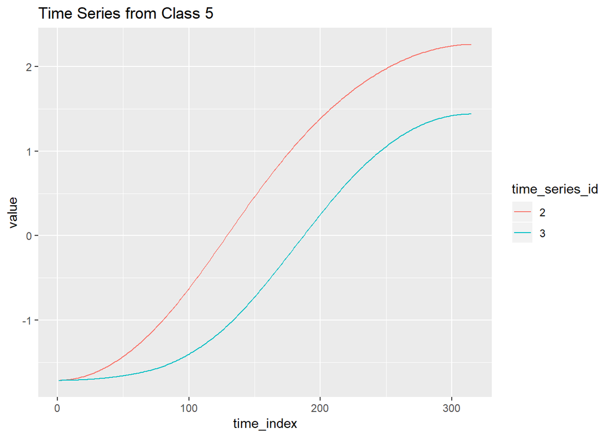

```r
pre5 = predict(pirinc5,xyz_5[,3:5])
xyz_5_uni = mutate(xyz_5,value=pre5[,1])
xyz_5_uni = mutate(xyz_5_uni, time_series_id=as.factor(time_series_id), time_index=as.numeric(time_index))
xyz_5_uni = subset(xyz_5_uni,select=-c(X,Y,Z))
xyz_5_uni = filter(xyz_5_uni, time_series_id==indexess[5] | time_series_id==indexess[13])
ggplot(xyz_5_uni) + geom_line(aes(x=time_index, y=value, colour=time_series_id)) + xlab("time_index") + ylab("value")+ ggtitle("Time Series from Class 5")
```

```r
#class6

xyz_6 = subset(xyz_pos_long, class==6)
pirinc6=princomp(xyz_6[,3:5], cor = TRUE)
print(summary(pirinc6,loadings=TRUE))
```

```
## Importance of components:
##                           Comp.1    Comp.2     Comp.3
## Standard deviation     1.3400570 0.9638120 0.52470332
## Proportion of Variance 0.5985843 0.3096445 0.09177119
## Cumulative Proportion  0.5985843 0.9082288 1.00000000
##
## Loadings:
##   Comp.1 Comp.2 Comp.3
## X  0.291  0.955
## Y -0.671  0.251 -0.698
## Z -0.682  0.162  0.713
```

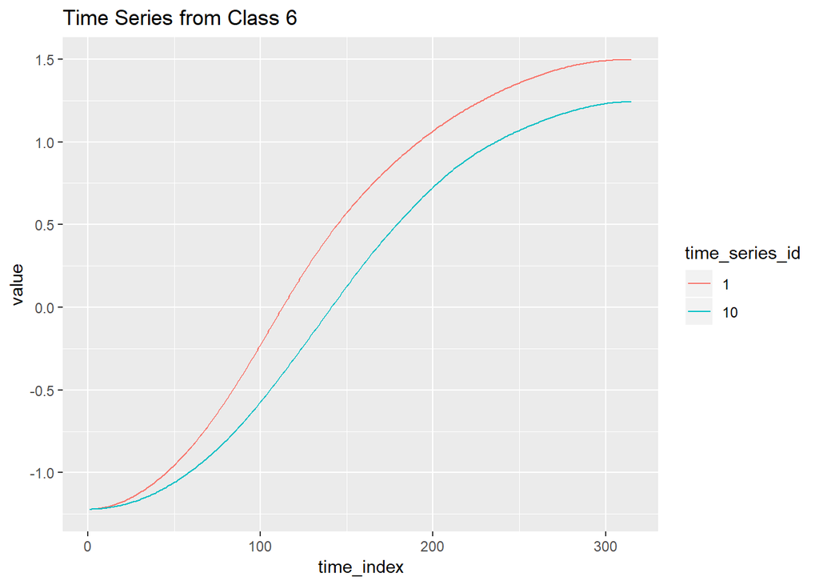

```r
pre6 = predict(pirinc6,xyz_6[,3:5])
xyz_6_uni = mutate(xyz_6,value=pre6[,1])
xyz_6_uni = mutate(xyz_6_uni, time_series_id=as.factor(time_series_id), time_index=as.numeric(time_index))
xyz_6_uni = subset(xyz_6_uni,select=-c(X,Y,Z))
xyz_6_uni = filter(xyz_6_uni, time_series_id==indexess[6] | time_series_id==indexess[14])
ggplot(xyz_6_uni) + geom_line(aes(x=time_index, y=value, colour=time_series_id)) + xlab("time_index") + ylab("value")+ ggtitle("Time Series from Class 6")
```

```r
#class7

xyz_7 = subset(xyz_pos_long, class==7)
pirinc7=princomp(xyz_7[,3:5], cor = TRUE)
print(summary(pirinc7,loadings=TRUE))
```

```
## Importance of components:
##                           Comp.1    Comp.2    Comp.3
## Standard deviation     1.2971922 0.8883869 0.7266781
## Proportion of Variance 0.5609026 0.2630771 0.1760203
## Cumulative Proportion  0.5609026 0.8239797 1.0000000
##
## Loadings:
##   Comp.1 Comp.2 Comp.3
## X  0.596  0.487  0.639
## Y  0.632  0.207 -0.747
## Z  0.496 -0.849  0.184
```

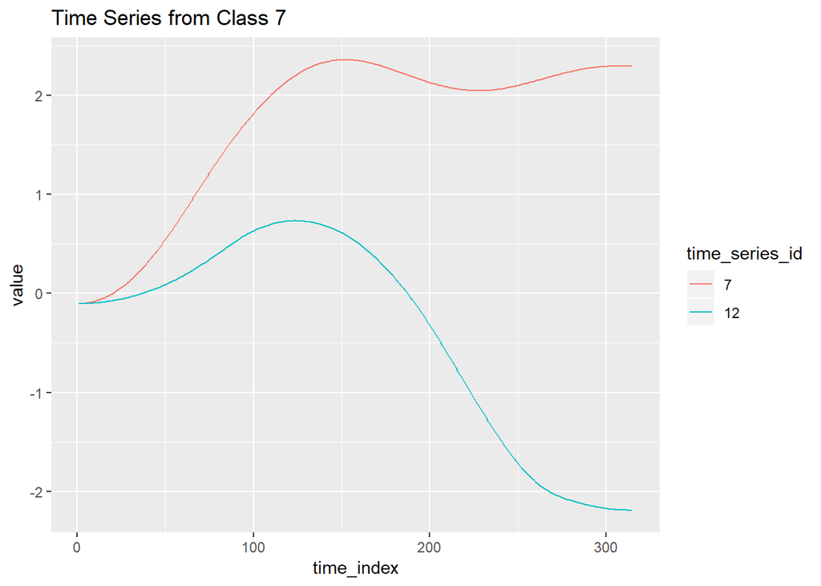

```r
pre7 = predict(pirinc7,xyz_7[,3:5])
xyz_7_uni = mutate(xyz_7,value=pre7[,1])
xyz_7_uni = mutate(xyz_7_uni, time_series_id=as.factor(time_series_id), time_index=as.numeric(time_index))
xyz_7_uni = subset(xyz_7_uni,select=-c(X,Y,Z))
xyz_7_uni = filter(xyz_7_uni, time_series_id==indexess[7] | time_series_id==indexess[15])

ggplot(xyz_7_uni) + geom_line(aes(x=time_index, y=value, colour=time_series_id)) + xlab("time_index") + ylab("value")+ ggtitle("Time Series from Class 7")
```

```r
#class8

xyz_8 = subset(xyz_pos_long, class==8)
pirinc8=princomp(xyz_8[,3:5], cor = TRUE)
print(summary(pirinc8,loadings=TRUE))
```

```
## Importance of components:
##                           Comp.1    Comp.2    Comp.3
## Standard deviation     1.2203138 0.9683089 0.7571078
## Proportion of Variance 0.4963886 0.3125407 0.1910707
## Cumulative Proportion  0.4963886 0.8089293 1.0000000
##
## Loadings:
##   Comp.1 Comp.2 Comp.3
## X  0.664  0.253  0.704
## Y  0.337 -0.941
## Z  0.668  0.223 -0.710
```

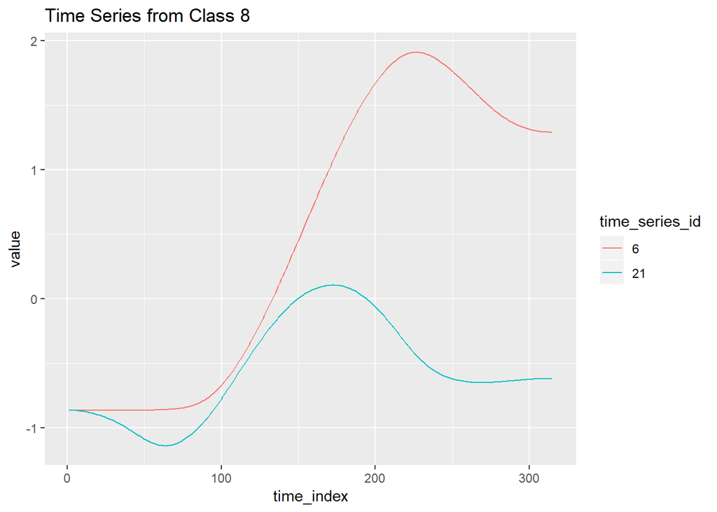

```r
pre8 = predict(pirinc8,xyz_8[,3:5])
xyz_8_uni = mutate(xyz_8,value=pre8[,1])
xyz_8_uni = mutate(xyz_8_uni, time_series_id=as.factor(time_series_id), time_index=as.numeric(time_index))
xyz_8_uni = subset(xyz_8_uni,select=-c(X,Y,Z))
xyz_8_uni = filter(xyz_8_uni, time_series_id==indexess[8] | time_series_id==indexess[16])

ggplot(xyz_8_uni) + geom_line(aes(x=time_index, y=value, colour=time_series_id)) + xlab("time_index") + ylab("value")+ ggtitle("Time Series from Class 8")
```

For the gestures, the percentages of the variance covered by the first components can be found as 56%, 42%, 49%, 55%, 66%, 60%, 56% and 50%, respectively. Hence, we can say that gesture class 2 and gesture class 5 have different characteristics in terms of their first component than remaining gesture classes.

## Part (d)

First, we calculated distincas by euclidian method. Then, applied multi-dimensional scaling to distance matrix to represent each time series on a 2-dimensional feature space.

Then, each point for gestures are plotted on the graph. Howver, gestures cannot be separated easily by this graph. For example, 1 and 5 are look distinguishable, whereas 1 and 6 are indistinguishable.

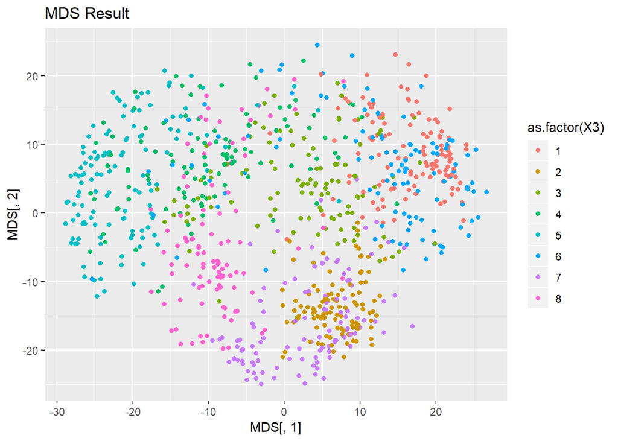

```r
xyz_bind = cbind(x_tr,y_tr[,-1],z_tr[,-1])
bind_without_class=scale(xyz_bind[,-1])
distance_btw = as.matrix(dist(bind_without_class, method="euclidian"))
MDS = cmdscale(distance_btw)

yepyeni = data.frame(cbind(MDS[,1],MDS[,2],xyz_bind[,1]))

ggplot(yepyeni,aes(x=MDS[,1],y=MDS[,2],color=as.factor(X3)))+geom_point()+ ggtitle("MDS Result")
```